# STAT 561 - Homework 2

Group Members: Asha Shah | Prabhath Pasula | Rithwik Reddy Nandyala

April 14, 2025

## Introduction

In this task, we discuss the problem of absenteeism in the modern dynamic workplace environment using logistic regression. We are attempting to forecast and understand the patternsof absenteeism founded on a diverse dataset of a Brazilian courier company. Also, we are studying flu shot statistics to learn the determinants of flu vaccination uptake.

## Setup

```r
library(dplyr)
library(readxl)
library(nnet)
library(GGally)
library(tidyverse)
library(MASS)
```

#__________________________ # Absenteeism Data Analysis #__________________________

### Question (a): How is the ‘Absenteeism time in hours’ distributed? Are there

### any noticeable patterns or outliers?

#### Explanation

Exploratory Data Analysis (EDA) involves summarizing the main characteristics of a dataset by using visual methods. This step is crucial to understand the structure of the data, identify patterns, detect outliers, and check assumptions before performing further analysis.

#### Code

```r
# Load and prepare the data
absent = read_excel("Absenteeism_at_work.xls")
names(absent) #column names
```

```
##  [1] "ID"                              "Month_of_absence"
##  [3] "Day_of_the_week"                 "Seasons"
##  [5] "Transportation_expense"          "Distance_from_Residence_to_Work"
##  [7] "Service_time"                    "Age"
##  [9] "Work_load_Average_in_days"       "Education"
## [11] "Son"                             "Pet"
## [13] "Weight"                          "Height"
## [15] "Body_mass_index"                 "Absenteeism_time_in_hours"
```

```r
# Recode absenteeism into categories
absent <- absent %>%
  mutate(absenteeism = case_when(
    Absenteeism_time_in_hours >= 0 & Absenteeism_time_in_hours <= 20 ~ "Low",
    Absenteeism_time_in_hours > 20 & Absenteeism_time_in_hours <= 40 ~ "Moderate",
    Absenteeism_time_in_hours > 40 ~ "High"
  ))


# Convert categorical variables to factors
absent$absenteeism <- factor(absent$absenteeism, levels = c("Low", "Moderate", "High"))
absent$Day_of_the_week <- factor(absent$Day_of_the_week,
                                  levels = 2:6,
                                  labels = c("Monday", "Tuesday", "Wednesday",
                                             "Thursday", "Friday"))
absent$Seasons <- factor(absent$Seasons,
                         levels = 1:4,
                         labels = c("Summer", "Autumn", "Winter", "Spring"))
absent$Education <- factor(absent$Education,
                           levels = 1:4,
                           labels = c("High School", "Graduate", "Postgraduate",
                                      "Master/Doctor"))


# Summary statistics to identify patterns and outliers
summary(absent$Absenteeism_time_in_hours)
```

```
##    Min. 1st Qu.  Median    Mean 3rd Qu.    Max.
##   0.000   2.000   3.000   6.924   8.000 120.000
```

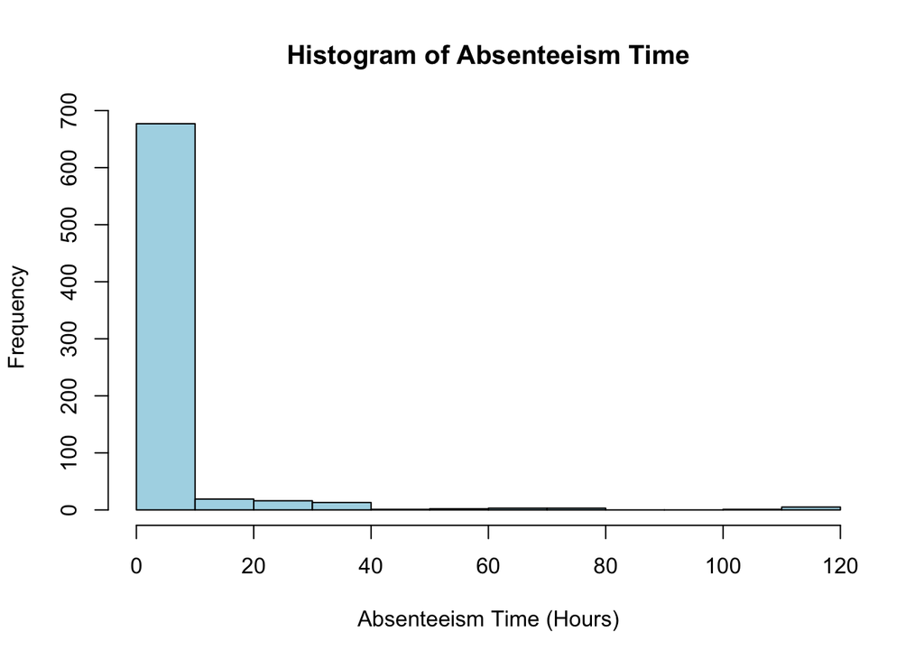

```r
#Analyze the distribution of 'Absenteeism time in hours'
# Histogram
hist(absent$Absenteeism_time_in_hours,
     main = "Histogram of Absenteeism Time",
     xlab = "Absenteeism Time (Hours)",
     col = "lightblue")
```

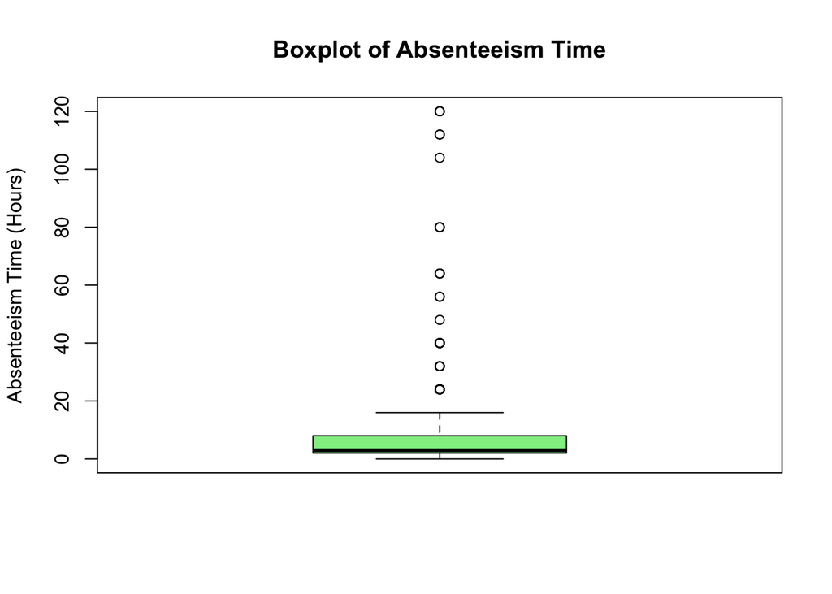

```r
# Boxplot to detect outliers
boxplot(absent$Absenteeism_time_in_hours,
        main = "Boxplot of Absenteeism Time",
        ylab = "Absenteeism Time (Hours)",
        col = "lightgreen")
```

#### Observations for Question (a)

```markdown
The histogram of Absenteeism time in hours is highly skewed to the right, with the
bulk of workers in the category of low absenteeism (0–10 hours). The histogram shows
a strong frequency at the lower end, and the boxplot highlights a few outliers at
absenteeism higher than 10 hours, as high as 120 hours. These outliers signal
occasional cases of extended absenteeism, which deserves further investigation.
Generally, data cluster around small values, but some extreme points pull the
upper tail of the distribution upwards.
```

### Question (b): What is the distribution of ages among the employees? Are certain

### age groups more prevalent?

#### Explanation

Understanding the distribution of a variable helps to know its spread, central tendency trend, and if there are any outliers. This is valuable information for selecting appropriate statistical methods for analysis. #### Code

```r
# Summary statistics for age
summary(absent$Age)
```

```
##    Min. 1st Qu.  Median    Mean 3rd Qu.    Max.
##   27.00   31.00   37.00   36.45   40.00   58.00
```

```r
# Categorize ages into groups
age_groups <- absent %>%
  mutate(age_group = case_when(
    Age >= 20 & Age <= 30 ~ "20-30",
    Age >= 31 & Age <= 40 ~ "31-40",
    Age >= 41 & Age <= 50 ~ "41-50",
    Age >= 51 & Age <= 60 ~ "51-60",
    Age > 60 ~ "61+"
  )) %>%
  group_by(age_group) %>%
  summarise(count = n())

# View the frequency of age groups
print(age_groups)
```

```
## # A tibble: 4 × 2
##   age_group count
##   <chr>     <int>
## 1 20-30       177
## 2 31-40       422
## 3 41-50       132
## 4 51-60         9
```

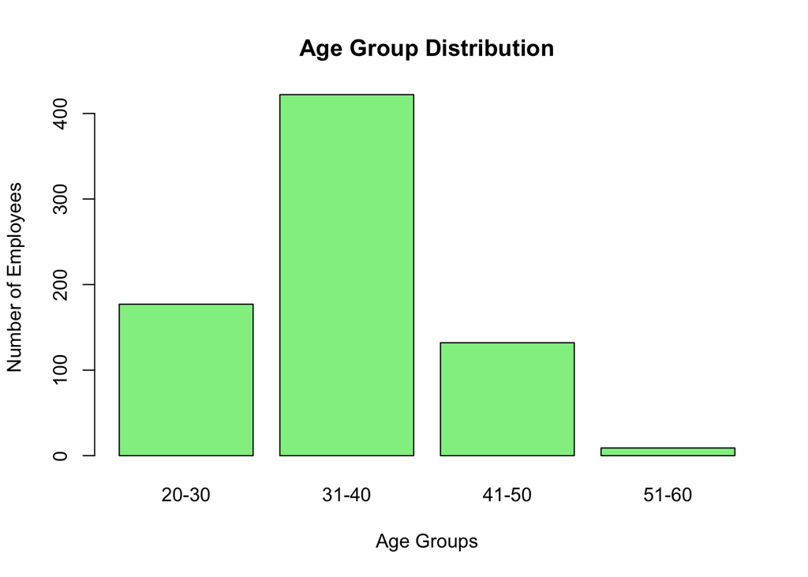

```r
# Bar chart of age groups
barplot(age_groups$count,
        names.arg = age_groups$age_group,
        main = "Age Group Distribution",
        xlab = "Age Groups",
        ylab = "Number of Employees",
        col = "lightgreen")
```

#### Observations for Question (b)

```markdown
The distribution of employees by age shows that most of the employees belong to
the 31–40 age group, with 422 employees, the most frequent. The second is the
20–30 age group, with 177 employees, and the 41–50 age group with 132 employees.
The least frequent age group is the 51–60 age group, with a total of 9 employees.

The summary statistics reveal the minimum age of 27, the maximum of 58, and the
median of 37, which tells us that the data is centered on mid-career employees.
The age distribution is roughly symmetric with the majority of employees having
ages between 31 and 40 years, as revealed by both the bar graph and the frequency
table. The structure of this population reveals an experienced workforce with the
majority of the employees not being too young or near retirement.
```

### Question (c): Is there a correlation between the distance from residence to work

### and absenteeism time?

#### Explanation

Understanding the correlation between home to workplace distance and absenteeism length can ascertain whether greater distances of commuting influence worker absenteeism. This can inform whether proximity to the workplace is a determining factor in workers’ work attendance. 1. Use a **scatter plot** to visualize the relationship between the two variables: `Distance_from_Residence_to_Work` and `Absenteeism_time_in_hours`. 2. Calculate the **correlation coefficient** to quantify the strength and direction of the relationship. 3. Interpret the results to determine if the distance significantly impacts absenteeism.

#### Code

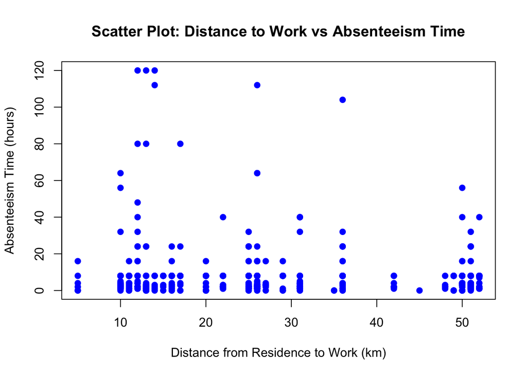

```r
# Scatter plot of distance vs absenteeism time
plot(absent$Distance_from_Residence_to_Work, absent$Absenteeism_time_in_hours,
     main = "Scatter Plot: Distance to Work vs Absenteeism Time",
     xlab = "Distance from Residence to Work (km)",
     ylab = "Absenteeism Time (hours)",
     col = "blue", pch = 19)
```

```r
# Calculate and display the Pearson correlation coefficient
correlation <- cor(absent$Distance_from_Residence_to_Work,
                   absent$Absenteeism_time_in_hours, method = "pearson")
correlation
```

```
## [1] -0.08836282
```

#### Observations for Question (c)

```markdown
The scatter plot and correlation coefficient both indicate no actual correlation
between Distance from Residence to Work and Absenteeism Time. The correlation
coefficient is -0.088, and that is effectively 0, which indicates no actual linear
relationship. This would imply that commute distance has no influence on absenteeism,
and other factors may be more significant.
```

### Question (d): How does the work load average per day relate to absenteeism? Are

### higher workloads associated with more or less absenteeism?

#### Code

```r
# Summary statistics for workload average per absenteeism category
aggregate(Work_load_Average_in_days ~ absenteeism, data = absent, mean)
```

| absenteeism | Work_load_Average_in_days |
| --- | --- |
| Low | 270579.9 |
| Moderate | 296701.5 |
| High | 264988.1 |

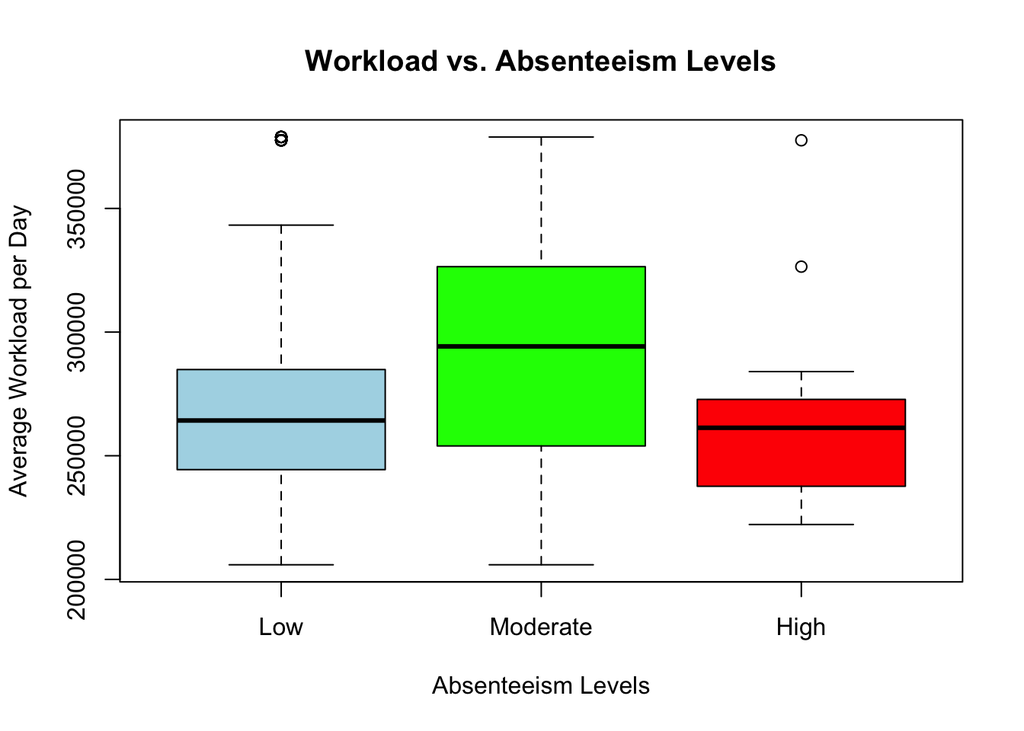

```r
# Boxplot to visualize workload vs absenteeism levels
boxplot(Work_load_Average_in_days ~ absenteeism, data = absent,
        main = "Workload vs. Absenteeism Levels",
        xlab = "Absenteeism Levels",
        ylab = "Average Workload per Day",
        col = c("lightblue", "green", "red"))
```

```r
# ANOVA test to check if differences are statistically significant
anova_result <- aov(Work_load_Average_in_days ~ absenteeism, data = absent)
summary(anova_result)
```

```
##              Df    Sum Sq   Mean Sq F value  Pr(>F)
## absenteeism   2 1.964e+10 9.822e+09   6.535 0.00154 **
## Residuals   737 1.108e+12 1.503e+09
## ---
## Signif. codes:  0 '***' 0.001 '**' 0.01 '*' 0.05 '.' 0.1 ' ' 1
```

#### Observations for Question (d)

```markdown
Higher workloads are associated with moderate absenteeism
(highest workload:296,701.5). An ANOVA test confirms the differences in
workload across absenteeism levels are statistically significant
((p = 0.00154)). However, high absenteeism corresponds to the lowest workload,
suggesting that excessive absenteeism may not directly result from higher
workloads.
```

### Question (e): Analyze the absenteeism based on education levels. Do certain

### education levels correlate with higher or lower absenteeism?

#### Explanation

To analyze absenteeism by education levels, we would like to know how absenteeism varies by different education levels. This involves:

Categorizing Data: Splitting the data into education levels (e.g., High School, Graduate, Postgraduate, Doctorate). Summarizing Absenteeism: Finding the frequency or proportion of the levels of absenteeism (Low, Moderate, High) for each level of education. Visual Interpretation: Use visual tools like bar plots to visualize trends across education levels. Statistical Testing: Fisher’s Exact Test is a statistical test used to determine whether there is a significant association (or relationship) between two categorical variables.

#### Code

```r
# Summary statistics: Count of absenteeism levels by education
education_absenteeism <- table(absent$Education, absent$absenteeism)
print(education_absenteeism)
```

```
##
##                 Low Moderate High
##   High School   571       26   14
##   Graduate       44        2    0
##   Postgraduate   77        1    1
##   Master/Doctor   4        0    0
```

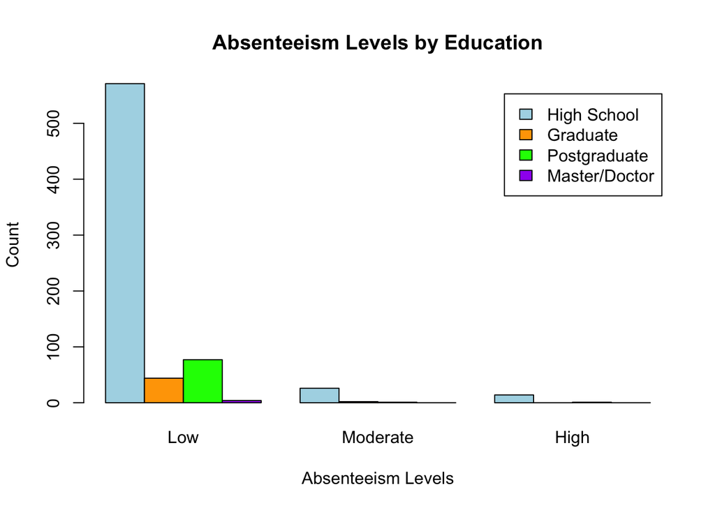

```r
# Barplot to visualize absenteeism by education level
barplot(education_absenteeism, beside = TRUE,
        col = c("lightblue", "orange", "green", "purple"),
        legend = rownames(education_absenteeism),
        main = "Absenteeism Levels by Education",
        xlab = "Absenteeism Levels",
        ylab = "Count")
```

```r
fisher_result <- fisher.test(education_absenteeism)
print(fisher_result)
```

```
##
##  Fisher's Exact Test for Count Data
##
## data:  education_absenteeism
## p-value = 0.8036
## alternative hypothesis: two.sided
```

#### Observations for Question (e)

```markdown
High school education dominates absenteeism, especially in the Low category,
while higher education levels (Graduate, Postgraduate, Master/Doctorate) show
minimal absenteeism. The Fisher's Exact Test produced a p-value of 0.8036, which
is much greater than 0.05.
This means there is no significant evidence to suggest that education levels and
absenteeism levels are correlated.
```

### Question (f): Which variables show the strongest correlation with

### absenteeism time in hours? How might these influence your logistic

### regression model?

#### Explanation

To discover which variables are most correlated with Absenteeism_time_in_hours, we compute Pearson correlation coefficients of absenteeism time with all other numeric variables in the data set. This will identify for us the variables most correlated with absenteeism. These can now be used as possible predictors in a logistic regression model.

#### Code

```r
# Compute correlation coefficients for numeric variables
correlation_matrix <- cor(absent[, sapply(absent, is.numeric)], use = "complete.obs")

# Extract correlations with Absenteeism_time_in_hours
absenteeism_correlations <- correlation_matrix["Absenteeism_time_in_hours", ]

# Sort correlations in descending order
sorted_correlations <- sort(absenteeism_correlations, decreasing = TRUE)

# Display the sorted correlations
print(sorted_correlations)
```

```
##       Absenteeism_time_in_hours                          Height
##                      1.00000000                      0.14442048
##                             Son                             Age
##                      0.11375650                      0.06575970
##          Transportation_expense       Work_load_Average_in_days
##                      0.02758463                      0.02474890
##                Month_of_absence                    Service_time
##                      0.02434536                      0.01902926
##                          Weight                              ID
##                      0.01578918                     -0.01799659
##                             Pet                 Body_mass_index
##                     -0.02827659                     -0.04971948
## Distance_from_Residence_to_Work
##                     -0.08836282
```

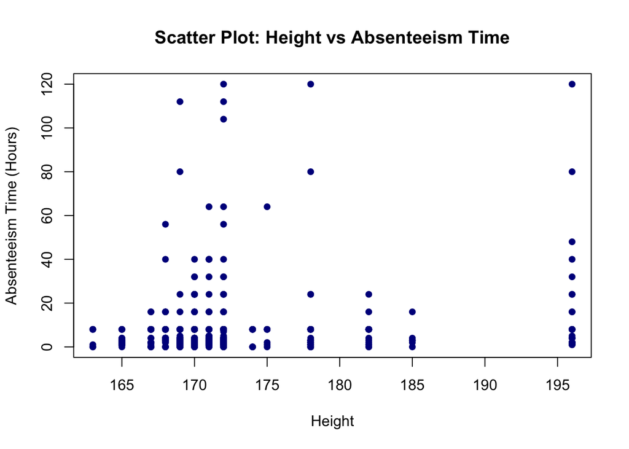

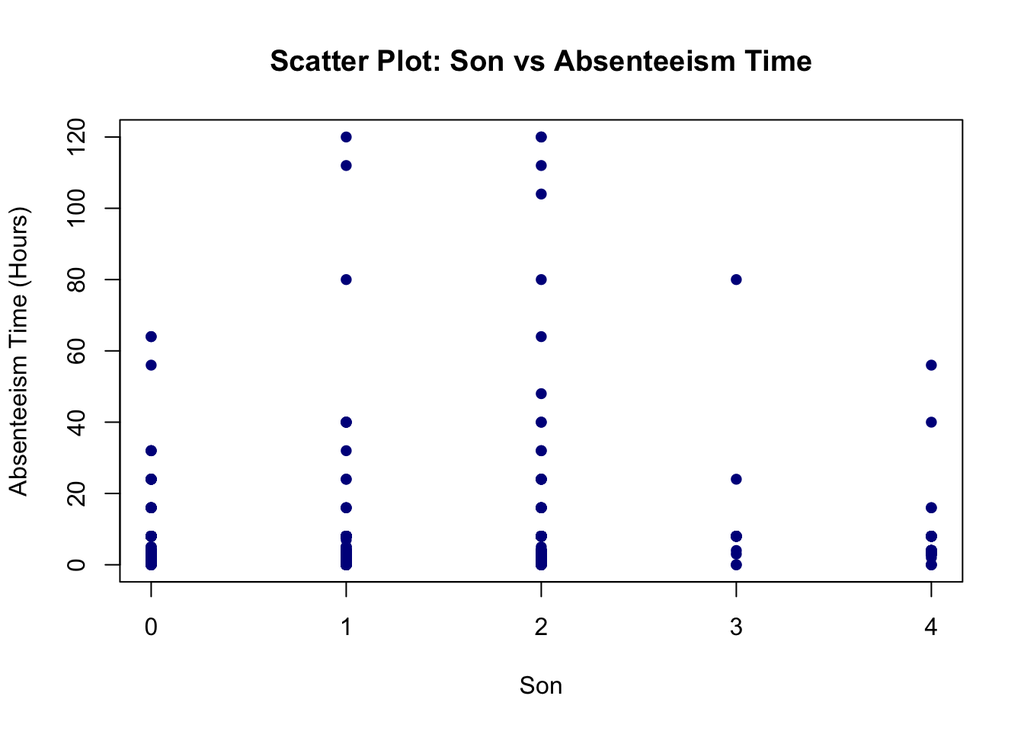

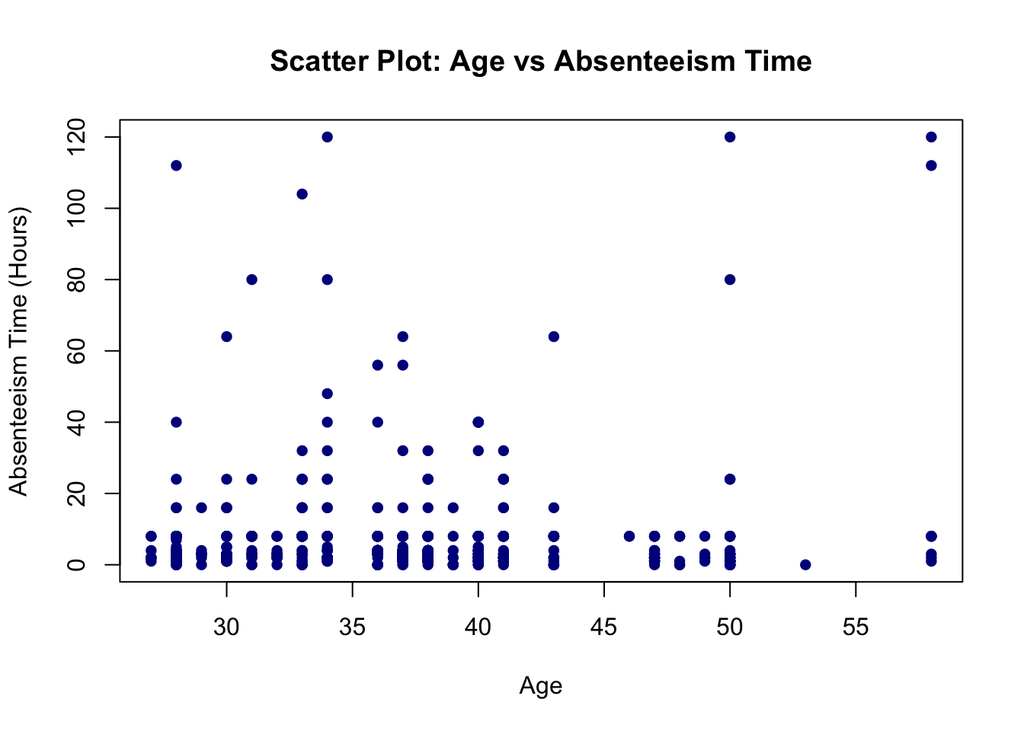

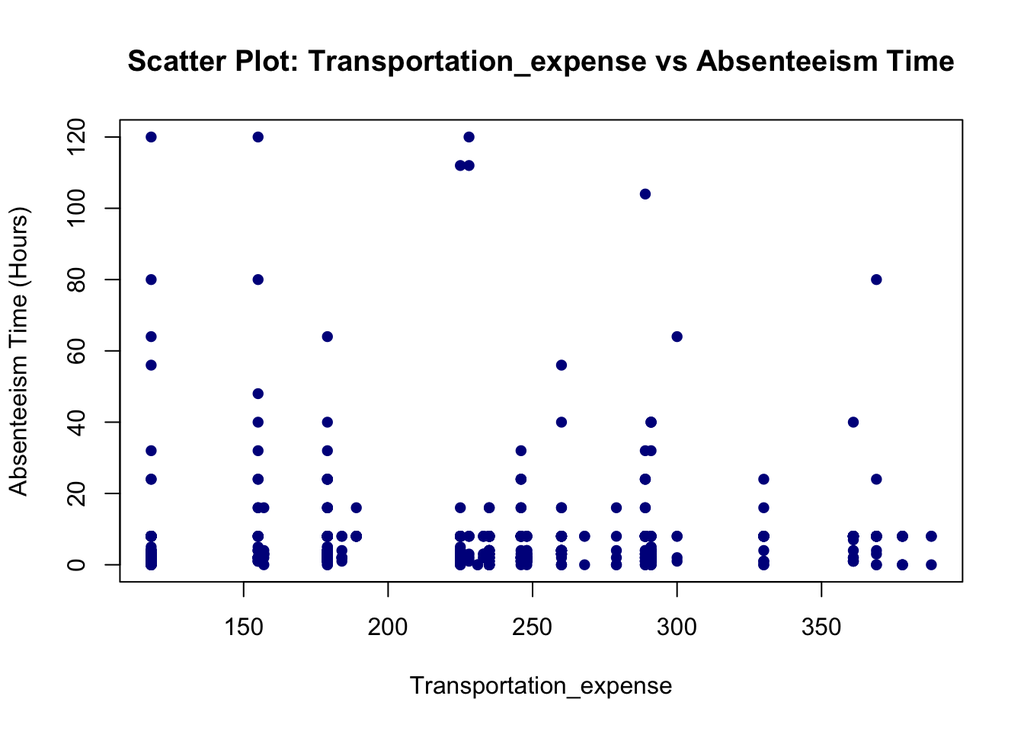

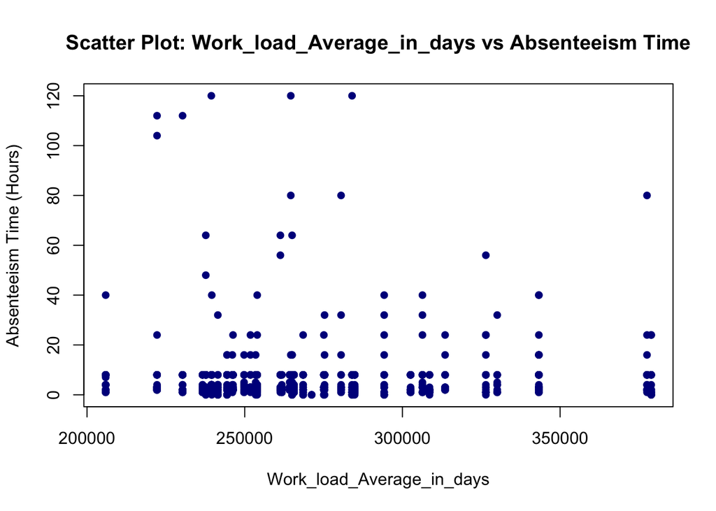

```r
# Select top 5 correlated variables (excluding absenteeism itself)
top_variables <- names(sorted_correlations)[2:6]

# Create scatter plots for the top correlated variables using Base R
for (var in top_variables) {
  # Create the scatter plot
  plot(absent[[var]], absent$Absenteeism_time_in_hours,
       main = paste("Scatter Plot:", var, "vs Absenteeism Time"),
       xlab = var,
       ylab = "Absenteeism Time (Hours)",
       col = "darkblue",
       pch = 16) # Use circular points
}
```